# Early-warnings signals in ecological systems Sesión 3

Roberto Álvarez. Universidad Autónoma de Querétaro

09 July, 2025

# 1 Métricas alternativas de estabilidad

Este tutorial presenta **métricas de estabilidad** que son **distintas** a las señales de alerta temprana (EWS, por sus siglas en inglés) basadas en el **fenómeno de desaceleración crítica** (*critical slowing down*, CSD). Es decir, **no se enfocan en detectar transiciones críticas observando cómo el sistema se vuelve más lento para recuperarse ante perturbaciones**.

Lo que hace valioso a este conjunto de técnicas es que **no retraduccn que el sistema esté en equilibrio**, ni tampoco**suponen ningún modelo matemático subyacente específico**. Esto las vuelve especialmente útiles para analizar sistemas reales complejos, donde a menudo **no se conoce bien el modelo dinámico** o** el sistema está en constante cambio**, sin alcanzar un punto estable.

El paquete `EWSmethods` en R ofrece **tres enfoques diferentes** para cuantificar la estabilidad de un sistema a partir de datos de series de tiempo, **independientemente de que haya o no una transición crítica inminente**.  
A lo largo del tutorial se explicará cada uno de estos métodos, paso a paso, y se incluirán ejemplos prácticos para mostrar cómo se aplican.

- Mientras que las EWS tradicionales buscan detectar **transiciones críticas** (como el colapso de un lago o un cambio brusco en una población) mediante indicadores como la varianza, la autocorrelación, etc.,**estos métodos alternativos de estabilidad pueden evaluar la resiliencia del sistema sin que se esté acercando necesariamente a un tipping point**.
- Al ser **modelo-libre** (*model-free*) y **equilibrio-libre** (*equilibrium-free*), estos métodos pueden aplicarse a sistemas:
  - Que están lejos del equilibrio.
  - Con múltiples forzamientos externos.
  - En los que no se pueden definir bien las variables de estado ni las tasas de cambio.

```r
library(EWSmethods) # Asegúrate de tenerlo instalado
library(ggplot2) # Para visualización)
data("simTransComms") # Carga el objeto en memoria

# Explora rápidamente su estructura
str(simTransComms)
```

[output not shown]

[output cut: 54 more lines]

[output not shown]

```r
# Por ejemplo, veamos las primeras filas de la primera réplica
head(simTransComms$community1)
```

```
##     community_id time   spp_1   spp_2     spp_3   spp_4     spp_5 inflection_pt
## 603      1_255_1    1 0.03542 0.78649 107.15268 0.02892 109.54225         191.5
## 604      1_255_1    2 0.04221 0.71308 101.93399 0.03101 115.98305         191.5
## 605      1_255_1    3 0.03554 0.60220 108.32277 0.03184 105.73545         191.5
## 606      1_255_1    4 0.03835 0.56748  98.40558 0.03074 114.34315         191.5
## 607      1_255_1    5 0.04052 0.55496 101.39460 0.03088  99.03568         191.5
## 608      1_255_1    6 0.03526 0.55473 110.97056 0.03024 119.30117         191.5
```

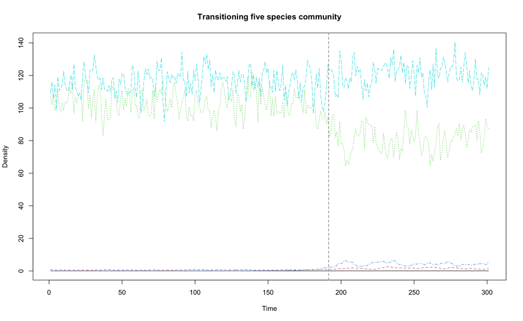

```r
matplot(simTransComms$community1[,3:7], type = "l", xlab = "Time", ylab = "Density",  main = "Transitioning five species community")
abline(v=simTransComms$community1$inflection_pt,col = "grey60", lty = "dashed")
```

Ahora que contamos con un sistema (o comunidad) que está siendo sometido a **algún tipo de perturbación o estrés**, podemos aplicar**métricas de estabilidad**, tanto univariadas como multivariadas, para evaluar **cómo responde el sistema**a esa presión externa.

Estas métricas no necesariamente detectan una transición crítica en sí misma, pero nos dan pistas sobre **la pérdida progresiva de estabilidad o resiliencia**, lo cual puede preceder a un cambio abrupto en la dinámica del sistema.

## 1.1 ÍNDICE DE VARIABILIDAD MULTIVARIADO (MVI)

Una de las métricas más simples incluidas en`EWSmethods`es el **índice de variabilidad multivariado (MVI, por sus siglas en inglés)**, propuesto por **Brock y Carpenter (2006)**.

**¿Qué mide exactamente?**  
El **MVI** se define como la **raíz cuadrada del valor propio dominante** (el mayor) de la **matriz de covarianza** de todas las especies en la comunidad.

- La matriz de covarianza refleja **cómo varían las especies en conjunto**.
- El valor propio dominante captura la **dirección de máxima varianza conjunta**.
- Al tomar la raíz cuadrada, se obtiene una métrica directa de variabilidad general del sistema.

Sea $\mathbf{X} = \begin{bmatrix} X_1 \\ X_2 \\ \vdots \\ X_n \end{bmatrix}$ un vector aleatorio de $n$ variables aleatorias.

La (o matriz de covarianzas) se define como:

$$\mathbf{\Sigma} = \mathrm{Cov}(\mathbf{X}) =
\begin{bmatrix}
\mathrm{Var}(X_1) & \mathrm{Cov}(X_1, X_2) & \cdots &
\mathrm{Cov}(X_1, X_n) \\
\mathrm{Cov}(X_2, X_1) & \mathrm{Var}(X_2) & \cdots &
\mathrm{Cov}(X_2, X_n) \\
\vdots & \vdots & \ddots & \vdots \\
\mathrm{Cov}(X_n, X_1) & \mathrm{Cov}(X_n, X_2) & \cdots &
\mathrm{Var}(X_n)
\end{bmatrix}$$

### 1.1.1 **¿Cómo interpretar el MVI?**

- Si el **MVI aumenta con el tiempo**, eso **sugiere una disminución de la estabilidad** del sistema.
- En otras palabras, el sistema comienza a fluctuar más y de forma más sincronizada entre especies, lo cual es una señal de que **la comunidad puede estar acercándose a una transición o pérdida de resiliencia**.

```r
egMVI <- mvi(data = simTransComms$community1[,2:7], winsize = 25)
```

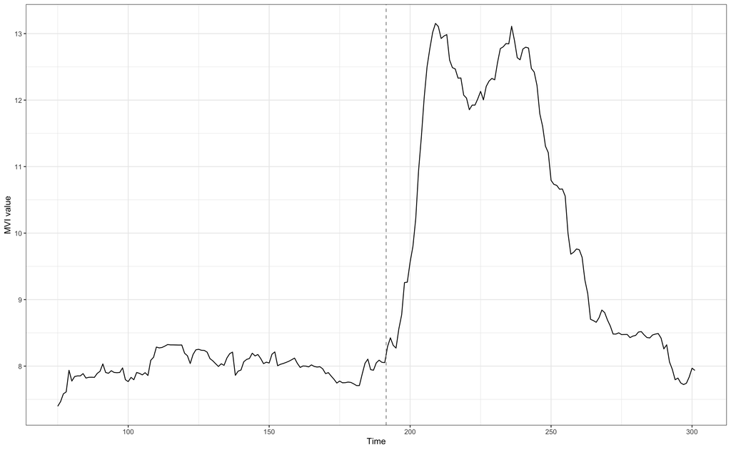

```r
mvi_plot_data <- merge(simTransComms$community1,as.data.frame(egMVI),by="time") # combine the mvi data with the raw time series

ggplot(mvi_plot_data,aes(x = time, y = mvi)) + geom_line() + geom_vline(xintercept = mvi_plot_data$inflection_pt,col = "grey60", linetype = "dashed") + theme_bw() + xlab("Time") + ylab("MVI value")
```

El índice MVI mide **únicamente cuánta variación hay en el sistema**, pero **no detecta si las interacciones entre las especies están cambiando**. Por eso, este indicador tiene algunas limitaciones importantes:

- Es **sensible a la calidad de los datos** (por ejemplo, errores de muestreo o falta de resolución temporal).
- Puede verse afectado por la **aleatoriedad natural** del sistema (ruido ecológico real).
- Su desempeño puede empeorar si el **forzamiento externo** (por ejemplo, una invasión, cambio climático, etc.) es **demasiado rápido**.

## 1.2 **Jacobianos estimados por S-map (S-MAP Jacobians)**

### 1.2.1 Introducción conceptual:

Estamos entrando en lo más reciente del análisis de estabilidad.  
Estas herramientas están basadas en el enfoque de **modelado dinámico empírico (EDM)** desarrollado por Sugihara y col. (2012).

La idea central de EDM se apoya en el **teorema de Takens (1981)**:

> *Es posible reconstruir la dinámica latente de un sistema (su atractor) a partir de una o más series de tiempo relacionadas.*

### 1.2.2 ¿Cómo se hace?

A través de una técnica llamada **“lag embedding”**, se construyen versiones desplazadas en el tiempo de las series originales. A partir de esas “copias”, el algoritmo **S-map** estima directamente **la matriz Jacobiana local**— una representación del comportamiento del sistema en ese instante.

### 1.2.3 ¿Y qué nos dice la matriz Jacobiana?

- Contiene las **derivadas parciales de primer orden**: describe cómo **cada variable (especie)** afecta a las demás.
- A través de sus **autovalores** (eigenvalues), obtenemos una medida de **estabilidad local** conocida como **estabilidad de Lyapunov**.

```r
eg_uniJI <- uniJI(data = simTransComms$community1[,2:3], winsize = 25, E = 3)
```

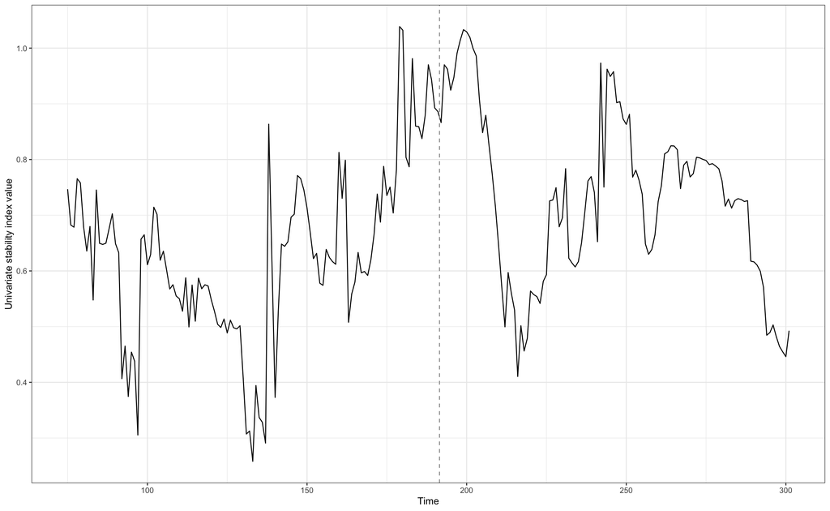

```r
uniJI_plot_data <- merge(simTransComms$community1,eg_uniJI,by="time") # combine the mvi data with the raw time series

ggplot(uniJI_plot_data,aes(x = time, y = smap_J)) + geom_line() + geom_vline(xintercept = uniJI_plot_data$inflection_pt,col = "grey60", linetype = "dashed") + theme_bw() + xlab("Time") + ylab("Univariate stability index value")
```

Para todas las especies, el índice de estabilidad univariada se puede ver en la siguiente gráfica

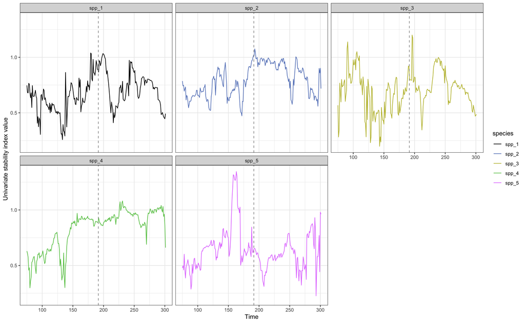

```r
all_spp_uniJI <- sapply(grep("spp_",colnames(simTransComms$community1)),FUN = function(x){
  if(x == 3){
  uniJI(data = simTransComms$community1[,c(2,x)], winsize = 25, E = 3)
  }else{
  uniJI(data = simTransComms$community1[,c(2,x)], winsize = 25, E = 3)[,2]
  }
  }) # for each species, calculate the univariate stability index

all_spp_uniJI <- do.call("cbind",all_spp_uniJI) # merge the list in to a data.frame
names(all_spp_uniJI) <- c("time",paste("spp",1:5,sep="_")) # and rename missing columns

all_spp_plot_data <- merge(stats::reshape(data = all_spp_uniJI,
        direction = "long",
        varying = colnames(all_spp_uniJI)[-1],
        v.names = "smap_J",
        times = colnames(all_spp_uniJI)[-1],
        timevar = "species"),
      simTransComms$community1[,c("time","inflection_pt")], by = "time") #pivot_longer for easier plotting and merge with the inflection point data

ggplot(all_spp_plot_data,aes(x = time, y = smap_J)) + geom_line(aes(col=species)) + geom_vline(xintercept = all_spp_plot_data$inflection_pt,col = "grey60", linetype = "dashed") + theme_bw() + xlab("Time") + ylab("Univariate stability index value") + scale_colour_manual(values = c("black","#6886c4","#bfbd3d","#69c756","#e281fe")) + facet_wrap(~species)
```

Este enfoque permite observar **cómo responde cada especie de forma única** a los cambios en el sistema.  
Al hacerlo, podemos **identificar cuáles especies son las más sensibles**, es decir, aquellas que reaccionan más rápido o más fuerte a perturbaciones. Estas especies pueden considerarse **especies indicadoras**, ya que reflejan de forma temprana la pérdida de estabilidad en toda la comunidad.

### 1.2.4 Implicación ecológica:

- Una especie con alta sensibilidad puede **anticipar una transición crítica** antes que otras.
- Esto es clave para **monitoreo ecológico**: en lugar de seguir a toda la comunidad, podrías enfocarte en unas cuantas especies clave.

### 1.2.5 ¿Qué hace`multiJI()`?

- Esta función estima un **modelo local lineal multivariado**, donde todas las especies se usan para **reconstruir el espacio de estados** del sistema.
- A partir de ahí, predice el siguiente estado de la comunidad.
- Los **coeficientes del modelo** sirven como **proxies (aproximaciones)** de las **fuerzas de interacción** entre especies.

🔗 Esto permite inferir **cómo influye cada especie sobre las demás**, sin necesidad de saber las ecuaciones que gobiernan el sistema.